# Lab 15.2

2026-02-26

## Learning Goals

*At the end of this exercise, you will be able to:*  
1. Use `shinydashboard` to improve ui aesthetics.

## Load the Libraries

```r
library(tidyverse)
library(shiny)
library(shinydashboard)
library(janitor)
```

## Load the Data

For this lab, we will use data on the gestation length of eutherian mammals. The data are from: Thodoris Danis, Antonis Rokas; The evolution of gestation length in eutherian mammals. Proc. Biol. Sci. 1 October 2024; 291 (2033): 20241412. https://doi.org/10.1098/rspb.2024.1412

```r
gestation <- read_csv("data/Data_S1.csv") %>%
  clean_names() %>%
  rename(gestationlength=gestationength)
```

```r
names(gestation)
```

```
## [1] "species"         "order"           "bodymass"        "longevity"
## [5] "gestationlength"
```

```r
gestation %>%
  distinct(order)
```

```
## # A tibble: 16 × 1
##    order
##    <chr>
##  1 Rodentia
##  2 Lagomorpha
##  3 Prosimians
##  4 Old_World_monkeys
##  5 New_World_monkeys
##  6 Yangochiroptera
##  7 Yinpterochiroptera
##  8 Artiodactyla
##  9 Cetacea
## 10 Carnivora
## 11 Pinnipeds
## 12 Perissodactyla
## 13 Eulipotyphla
## 14 Cingulata
## 15 Pilosa
## 16 Afrosoricida
```

## Aesthetics

There are many ways to adjust shiny apps for better visual appeal. Let’s start with some more practice and then add details.

1. Build an app that allows users to select a mammalian `order` and a variable of interest (body mass, longevity, or gestation length) and then plots the density distribution of that variable for the selected order.

```r
ui <- fluidPage(

  theme = shinythemes::shinytheme("cyborg"),

  titlePanel("Distribution of Gestation Length by Order"),

  selectInput("x",
              "Select Mammalian Order",
              choices = sort(unique(gestation$order)),
              selected = "Afrosoricida"),

  selectInput("y",
              "Select Variable of Interest",
              choices = c("bodymass",
                          "longevity",
                          "gestationlength"),
              selected = "bodymass"),

  plotOutput("plot",
             width = "600px",
             height = "500px")
)

server <- function(input, output, session) {

  output$plot <- renderPlot({

    gestation %>%
      ggplot(aes(x = .data[[input$x]],
                 y = .data[[input$y]],
                 )) +
      geom_density(alpha = 0.8) +
      labs(title = "Density Distribution",
           x = "Order",
           fill = "Variable of Interest") +
      theme_minimal()
  })

}

shinyApp(ui, server)
```

## ui Layout with `shinydashboard`

We have a functional app, but the layout doesn’t look very nice. We can change that with many different methods (and specialized libraries), but shiny dashboards are simple to use and offer a lot of functionality for making apps look professional quickly.

We won’t use `fluidPage()` with `shinydashboard` but rather `dashboardPage()`. A shiny dashboard contains a minimum of a header, a sidebar, and a body.

```r
ui <-
  dashboardPage(


  dashboardHeader(title = "This is the Header"),

  dashboardSidebar(title = "This is the Sidebar"),

  dashboardBody() # this is where the output will go
)

server <- function(input, output) { }

shinyApp(ui, server)
```

## Practice

Let’s try to build an app that allows users to explore sex composition of wolf packs by `pop`. These data are from: Brandell, Ellen E (2021), Serological dataset and R code for: Patterns and processes of pathogen exposure in gray wolves across North America, Dryad, [Dataset](https://doi.org/10.5061/dryad.5hqbzkh51)

1. Start by loading and exploring the data.

```r
wolves <- read_csv("data/wolves_data/wolves_dataset.csv") %>% clean_names()
```

```r
names(wolves)
```

```
##  [1] "pop"                "year"               "age_cat"
##  [4] "sex"                "color"              "lat"
##  [7] "long"               "habitat"            "human"
## [10] "pop_density"        "pack_size"          "standard_habitat"
## [13] "standard_human"     "standard_pop"       "standard_packsize"
## [16] "standard_latitude"  "standard_longitude" "cav_binary"
## [19] "cdv_binary"         "cpv_binary"         "chv_binary"
## [22] "neo_binary"         "toxo_binary"
```

2. For the app, here is a faceted version of what we are looking for. We want the reactive part to be `pop` and you should try to use `shinydashboard`.

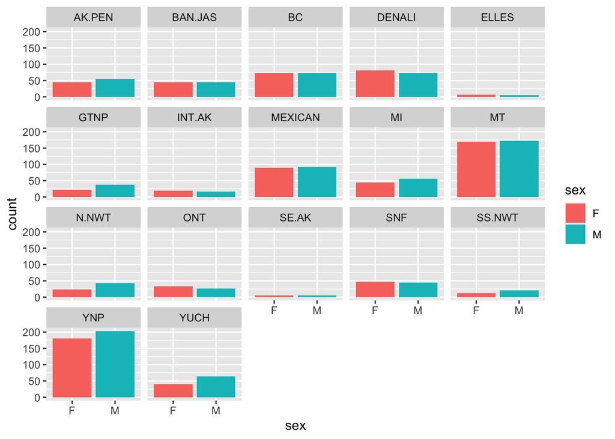

```r
wolves %>%
  filter(sex!="NA") %>%
  ggplot(aes(x=sex, fill=sex))+
  geom_bar()+
  facet_wrap(~pop)
```

–>[Home](https://jmledford3115.github.io/datascibiol/)